TAS is an acronym for Total Alkali vs. Silica. This type of plot is used to classify igneous rocks by comparing the weigh percentage of SiO2 with the weight percentage of NaO2 plus K20 in a particular rock sample. Specific ranges of this ratio are assigned a specific compositional classification.

TAS diagrams were first proposed by Lebas et al. in 1986 as a way to classify volcanic/plutonic rock without detailed modal mineral content information, such as with the QAPF ternary diagram. Lebas et al. used oxide content within a rock (specifically SiO2 vs. summed Na2O and K2O), instead of mineral content to discriminate different rock types. Lebas et al. original manuscript.

Here a classic TAS diagram modelled after the original Lebas et al. manuscript.

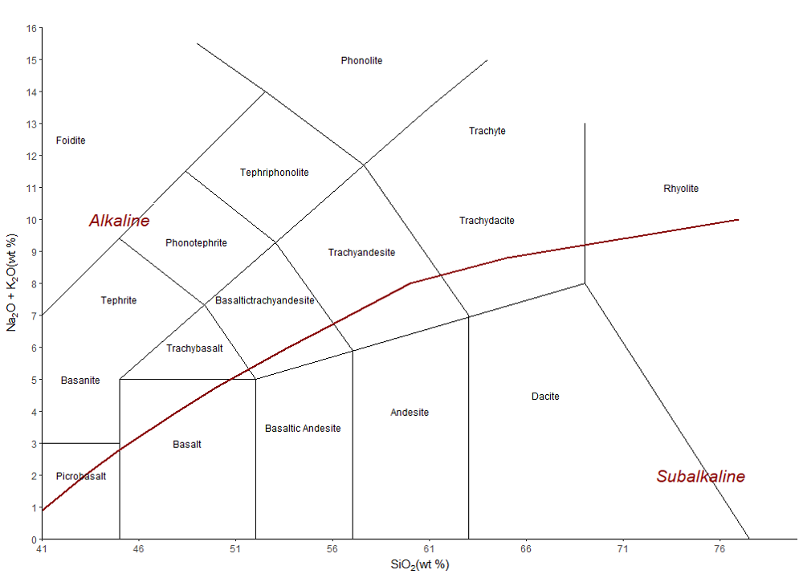

Geoscientists have used TAS diagrams regularly since their inception; they are even used to study rock beyond Earth. Here is a TAS diagram showing that most rock on Mars is basaltic in nature!

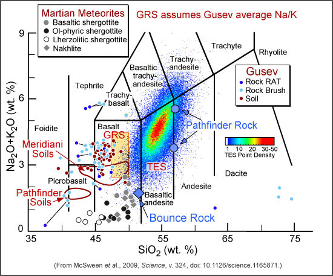

### How to input data:

Go to the Data tab inside the TAS tab. You will see a side panel that is titled ‘Load Your Data’. By default, no file is selected. Click on the ‘Browse.’ button, and navigate through your files to find the .xlsx file that contains your oxide data. Once you select your data, the ‘Input Data’ tab will display the entire spreadsheet from Excel.

Click the down arrow under ‘Select SiO2 variable:’, and choose the column in your spreadsheet that contains your weighted percentage of SiO2. Do the same for the field under ‘Select Na2O and K2O variables:’. You will select two columns from your spreadsheet; one will have the weighted percentage of Na2O and the other will have the weighted percentage of K2O. If you have a grouping variable you wish to use, such as sample location, select that column in the field beneath ‘Select grouping variable:’. If you do not have a grouping variable, the app will automatically populate all data points with the value ‘1’ as a grouping variable. The grouping variables are visually differentiated on the actual plot by color.

### Included default graph:

Go to the Plot tab inside the TAS tab. The polygons on this plot were created using the values in an R package called NORRRM, which in turns contains another package called TASplot. The names for rocks inside of each field refer to the extrusive variety. There are corresponding intrusive varieties to these rocks with the same parameters for each polygon; for example, basalt corresponds with gabbro.

If you have a grouping variable, you can selectively plot and exclude certain groups using the panel on the left side of the plot. You can also change the shape, size, and color of points in each group using controls on the bottom left of the Plot tab.

The right panel of the Plot tab gives you the option to create a title for your plot. You can also check and uncheck the box next to ‘Alkaline vs. Subalkaline’ in order to turn on and off a line on the plot that separates the alkaline and subalkaline rock types.

### How to download your plot:

You can download an image of your TAS plot as a .pdf or .png file using the down arrow under ‘Download Options:’. Once you have selected your file type, click the ‘Download’ button, and the image of your plot will be in the Downloads folder of your computer.